# Project

# Preparation

```r
library(readxl)
library(dplyr)
library(tidyverse)
```

# Data reading

```r
data <- read_excel("USA-median-mean-income-by-age.xlsx")
```

```r
data <- na.omit(data)
data <- data[c("Age Group", "2017\ndollars(Male Mean)", "2017\ndollars(Female Mean)")]
```

```r
print(colnames(data))
```

```
[1] "Age Group"                  "2017\ndollars(Male Mean)"
[3] "2017\ndollars(Female Mean)"
```

# Income with age

## EDA

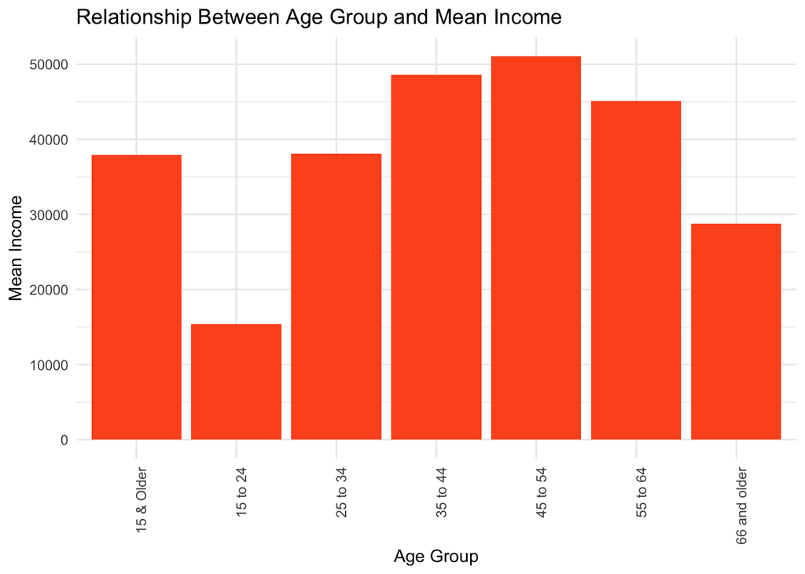

```r
data$CurrentTotalMean <- (data$`2017\ndollars(Male Mean)` + data$`2017\ndollars(Female Mean)`) / 2

age_income_mean <- data %>%
  group_by(`Age Group`) %>%
  summarise(MeanIncome = mean(CurrentTotalMean, na.rm = TRUE))

# Plotting the relationship between age group and mean income
ggplot(age_income_mean, aes(x = `Age Group`, y = MeanIncome)) +
  geom_bar(stat = "identity", fill = "#ff5722") +  # Use geom_col() if using ggplot2 version >= 2.2.0
  theme_minimal() +
  labs(title = "Relationship Between Age Group and Mean Income",
       x = "Age Group",
       y = "Mean Income") +
  theme(axis.text.x = element_text(angle = 90, hjust = 1))
```

## Hypothesis

Null Hypothesis $H_0$: There is no difference in mean income across different age groups. Alternative Hypothesis $H_a$: There is a difference in mean income across different age groups.

```r
new_data <- age_income_mean[-1, ]
```

## Anova

```r
age_income_mean$`Age Group` <- as.factor(age_income_mean$`Age Group`)
anova_result <- aov(MeanIncome ~ `Age Group`, data = age_income_mean)
summary(anova_result)
```

```
            Df    Sum Sq   Mean Sq
`Age Group`  6 931144825 155190804
```

## Kruskal-Wallis

```r
kruskal_test <- kruskal.test(MeanIncome ~ `Age Group`, data = age_income_mean)
kruskal_test
```

```
    Kruskal-Wallis rank sum test

data:  MeanIncome by Age Group
Kruskal-Wallis chi-squared = 6, df = 6, p-value = 0.4232
```

Therefore, based on this result, I would conclude that there is no significant difference in income across age groups since P-value is 0.4232, which is greater than the common alpha level of 0.05, at least not one detectable by this test with this data. This might be due to a truly non-existent difference, or it could be due to insufficient power (e.g., small sample sizes within groups, small differences between groups, high variability within groups, etc.).

## Advanced analysis to get deeper insights

Does the mean income peak at a certain age group and then decline or does it consistantly increase with age?

```r
age_group_mapping <- c("15 to 24" = 19.5, "25 to 34" = 29.5, "35 to 44" = 39.5, "45 to 54" = 49.5, "55 to 64" = 59.5, "65 and older" = 69.5)
new_data$AgeNumeric <- sapply(new_data$`Age Group`, function(x) age_group_mapping[x])
```

```r
model <- lm(MeanIncome ~ AgeNumeric, data = new_data)

summary(model)
```

```
Call:
lm(formula = MeanIncome ~ AgeNumeric, data = new_data)

Residuals:
    1     2     3     4     5
-9782  5678  8956  4183 -9035

Coefficients:
            Estimate Std. Error t value Pr(>|t|)
(Intercept)  11019.8    13427.1   0.821    0.472
AgeNumeric     724.9      320.0   2.265    0.108

Residual standard error: 10120 on 3 degrees of freedom
  (1 observation deleted due to missingness)
Multiple R-squared:  0.631, Adjusted R-squared:  0.508
F-statistic: 5.131 on 1 and 3 DF,  p-value: 0.1084
```

The p-value of 0.108 which is above the common alpha level of 0.05, suggesting that the relationship between age group and mean income is not statistically significant at the 5% level.

The rather small statistical significance may be due to a small sample size or high variability within age groups. With only 5 data points (after one was removed due to missingness), the power to detect significant effects is limited.

# Income inequality within diffent income group

## Data reading

```r
inequality <- read.csv("Income_Inequality_clean.csv")

head(inequality)
```

```
      Country Year Population         Incomegroup     Mean  Median  Gini
1 Afghanistan 2007  26.911530          Low income 36588.00      NA 29.00
2 Afghanistan 2008  27.658890          Low income       NA      NA 27.80
3     Albania 1996   3.092034 Upper middle income 58192.80      NA 28.00
4     Albania 2002   3.123112 Upper middle income  2256.96 1861.68 31.74
5     Albania 2005   3.082172 Upper middle income  2605.92 2217.48 30.60
6     Albania 2008   2.968026 Upper middle income  2850.24 2385.12 29.98
                                      Source   D1   D2   D3   D4   D5   D6
1 National Risk and Vulnerability Assessment   NA   NA   NA   NA   NA   NA
2                                 World Bank   NA   NA   NA   NA   NA   NA
3        Deininger & Squire, World Bank 2004 3.68 5.02 6.01 7.02 8.06 9.11
4                            World Bank 2016 3.49 4.86 5.84 6.74 7.65 8.84
5                            World Bank 2016 3.48 4.92 5.98 6.92 7.99 9.04
6                            World Bank 2016 3.73 5.14 6.09 6.98 7.91 8.92
     D7    D8    D9   D10   Q1    Q2    Q3    Q4    Q5 Quality
```

[output cut: 27 more lines]

```r
summary(inequality)
```

```
   Country               Year        Population        Incomegroup
 Length:5317        Min.   :1948   Min.   :   0.0801   Length:5317
 Class :character   1st Qu.:1991   1st Qu.:   5.1082   Class :character
 Mode  :character   Median :2000   Median :  12.5733   Mode  :character
                    Mean   :1997   Mean   :  62.3106
                    3rd Qu.:2008   3rd Qu.:  45.9181
                    Max.   :2015   Max.   :1362.5143
                                   NA's   :82
      Mean              Median              Gini          Source
 Min.   :      32   Min.   :     139   Min.   :14.60   Length:5317
 1st Qu.:    3372   1st Qu.:    2388   1st Qu.:31.86   Class :character
 Median :    8887   Median :    6300   Median :40.17   Mode  :character
 Mean   :  436142   Mean   :  217277   Mean   :40.66
 3rd Qu.:   26020   3rd Qu.:   16259   3rd Qu.:49.50
 Max.   :48271000   Max.   :45446400   Max.   :78.60
 NA's   :1879       NA's   :2955       NA's   :34
       D1             D2              D3              D4
 Min.   :0.00   Min.   :0.200   Min.   :0.500   Min.   :0.800
 1st Qu.:1.30   1st Qu.:2.600   1st Qu.:3.530   1st Qu.:4.540
 Median :2.04   Median :3.530   Median :4.600   Median :5.610
 Mean   :2.24   Mean   :3.681   Mean   :4.702   Mean   :5.697
 3rd Qu.:3.12   3rd Qu.:4.800   3rd Qu.:5.900   3rd Qu.:6.910
 Max.   :7.00   Max.   :7.600   Max.   :8.100   Max.   :9.600
 NA's   :580    NA's   :585     NA's   :592     NA's   :592
       D5               D6               D7              D8
 Min.   : 1.500   Min.   : 2.700   Min.   : 4.24   Min.   : 6.25
 1st Qu.: 5.650   1st Qu.: 7.000   1st Qu.: 8.80   1st Qu.:11.34
 Median : 6.800   Median : 8.100   Median : 9.73   Median :11.89
 Mean   : 6.764   Mean   : 7.996   Mean   : 9.55   Mean   :11.71
 3rd Qu.: 7.990   3rd Qu.: 9.100   3rd Qu.:10.43   3rd Qu.:12.20
 Max.   :10.800   Max.   :12.000   Max.   :12.45   Max.   :16.30
 NA's   :592      NA's   :592      NA's   :592     NA's   :592
       D9             D10              Q1               Q2
 Min.   : 8.00   Min.   :15.70   Min.   : 0.300   Min.   : 1.30
 1st Qu.:14.71   1st Qu.:24.70   1st Qu.: 3.920   1st Qu.: 8.20
 Median :15.50   Median :31.50   Median : 5.790   Median :10.49
 Mean   :15.44   Mean   :32.23   Mean   : 5.977   Mean   :10.49
 3rd Qu.:16.20   3rd Qu.:39.16   3rd Qu.: 7.970   3rd Qu.:12.83
 Max.   :24.00   Max.   :70.24   Max.   :14.600   Max.   :17.70
 NA's   :582     NA's   :572
```

[output cut: 21 more lines]

```



 Welfaredefn_new    Equivsc_new        AreaCovr_new       IncSharU_new
 Length:5317        Length:5317        Length:5317        Length:5317
 Class :character   Class :character   Class :character   Class :character
 Mode  :character   Mode  :character   Mode  :character   Mode  :character




 UofAnala_new
 Length:5317
 Class :character
 Mode  :character
```

```r
str(inequality)
```

```
'data.frame':   5317 obs. of  37 variables:
 $ Country         : chr  "Afghanistan" "Afghanistan" "Albania" "Albania" ...
 $ Year            : int  2007 2008 1996 2002 2005 2008 2012 1988 1995 2000 ...
 $ Population      : num  26.91 27.66 3.09 3.12 3.08 ...
 $ Incomegroup     : chr  "Low income" "Low income" "Upper middle income" "Upper middle income" ...
 $ Mean            : num  36588 NA 58193 2257 2606 ...
 $ Median          : num  NA NA NA 1862 2217 ...
 $ Gini            : num  29 27.8 28 31.7 30.6 ...
 $ Source          : chr  "National Risk and Vulnerability Assessment" "World Bank" "Deininger & Squire, World Bank 2004" "World Bank 2016" ...
 $ D1              : num  NA NA 3.68 3.49 3.48 3.73 3.66 2.56 2.87 0.98 ...
 $ D2              : num  NA NA 5.02 4.86 4.92 5.14 5.19 3.98 4.1 2.2 ...
 $ D3              : num  NA NA 6.01 5.84 5.98 6.09 6.14 4.93 5.22 3.34 ...
 $ D4              : num  NA NA 7.02 6.74 6.92 6.98 7.03 5.86 6.33 4.5 ...
 $ D5              : num  NA NA 8.06 7.65 7.99 7.91 8.08 6.85 7.48 5.66 ...
 $ D6              : num  NA NA 9.11 8.84 9.04 8.92 9.26 7.97 8.75 7.05 ...
```

[output cut: 23 more lines]

## EDA

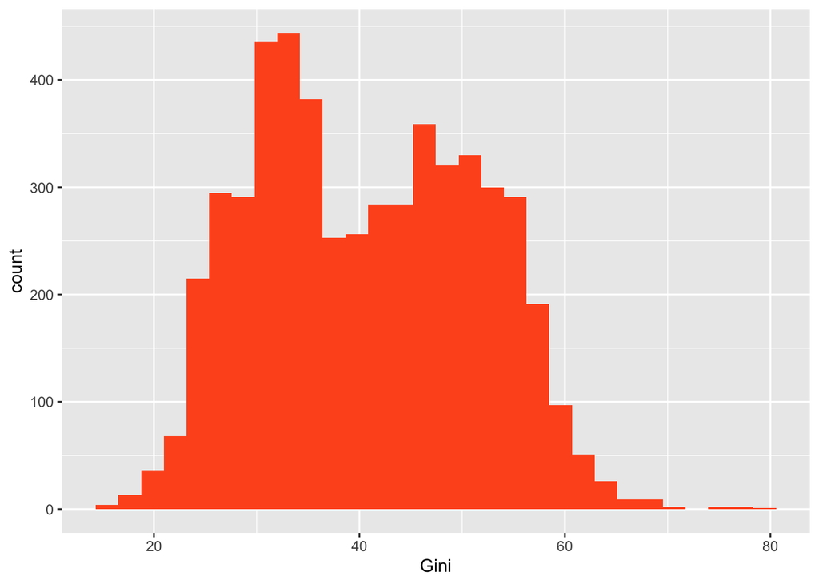

```r
gini_income_data <- inequality %>%
  select(Gini, Incomegroup) %>%
  na.omit()

grouped_summary <- gini_income_data %>%
  group_by(Incomegroup) %>%
  summarise(Mean_Gini = mean(Gini), Median_Gini = median(Gini), sd_Gini = sd(Gini))

# Count of countries per income group
ggplot(gini_income_data, aes(x = Gini)) + geom_histogram(bins = 30, fill = "#ff5722")
```

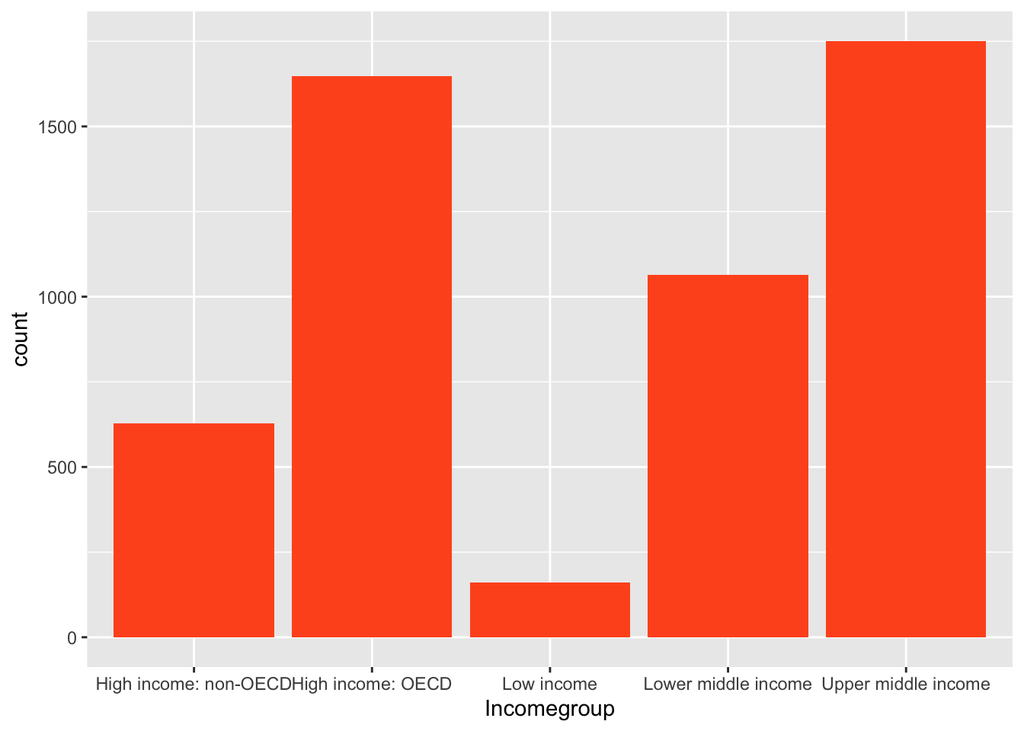

```r
# Gini trend over the years
ggplot(gini_income_data, aes(x = Incomegroup)) + geom_bar(fill = "#ff5722")
```

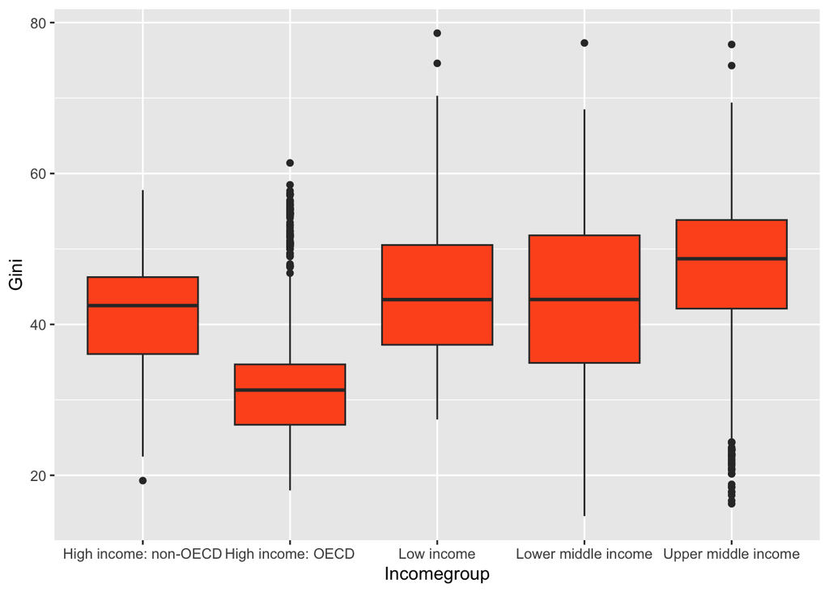

```r
# Boxplot
ggplot(gini_income_data, aes(x = Incomegroup, y = Gini)) + geom_boxplot(fill = "#ff5722")
```

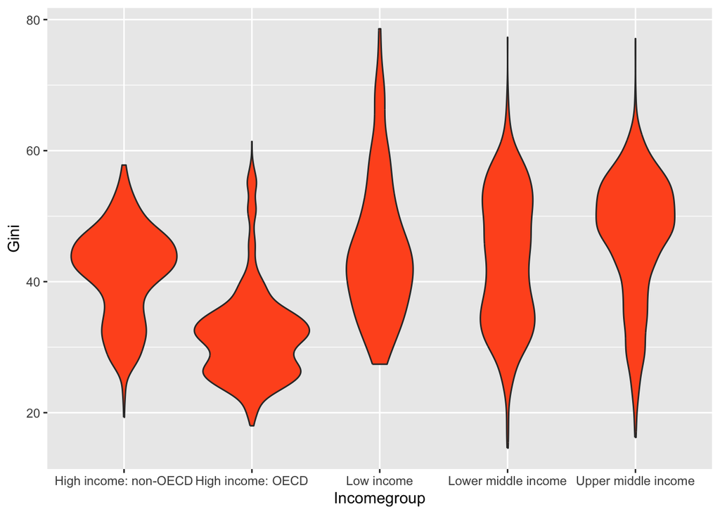

```r
# Violin plot
ggplot(gini_income_data, aes(x = Incomegroup, y = Gini)) + geom_violin(fill = "#ff5722")
```

## Hypothesis Test

Null Hypothesis $H_0$: There is no significant differences in income inequality across different income groups. Alternative Hypothesis $H_a$: There is a significant differences in income inequality across different income groups.

## ANOVA

```r
anova_result <- aov(Gini ~ Incomegroup, data = gini_income_data)
summary(anova_result)
```

```
              Df Sum Sq Mean Sq F value Pr(>F)
Incomegroup    4 209105   52276   688.4 <2e-16 ***
Residuals   5246 398404      76
---
Signif. codes:  0 '***' 0.001 '**' 0.01 '*' 0.05 '.' 0.1 ' ' 1
```

## Regression

```r
lm_model <- lm(Gini ~ Incomegroup, data = gini_income_data)
summary(lm_model)
```

```
Call:
lm(formula = Gini ~ Incomegroup, data = gini_income_data)

Residuals:
    Min      1Q  Median      3Q     Max
-30.728  -5.809   0.491   5.577  33.975

Coefficients:
                               Estimate Std. Error t value Pr(>|t|)
(Intercept)                     41.3229     0.3478 118.829  < 2e-16 ***
IncomegroupHigh income: OECD    -9.5139     0.4087 -23.278  < 2e-16 ***
IncomegroupLow income            3.5311     0.7717   4.576 4.86e-06 ***
IncomegroupLower middle income   2.0021     0.4385   4.566 5.08e-06 ***
IncomegroupUpper middle income   5.6351     0.4053  13.902  < 2e-16 ***
---
Signif. codes:  0 '***' 0.001 '**' 0.01 '*' 0.05 '.' 0.1 ' ' 1

Residual standard error: 8.715 on 5246 degrees of freedom
Multiple R-squared:  0.3442,    Adjusted R-squared:  0.3437
F-statistic: 688.4 on 4 and 5246 DF,  p-value: < 2.2e-16
```